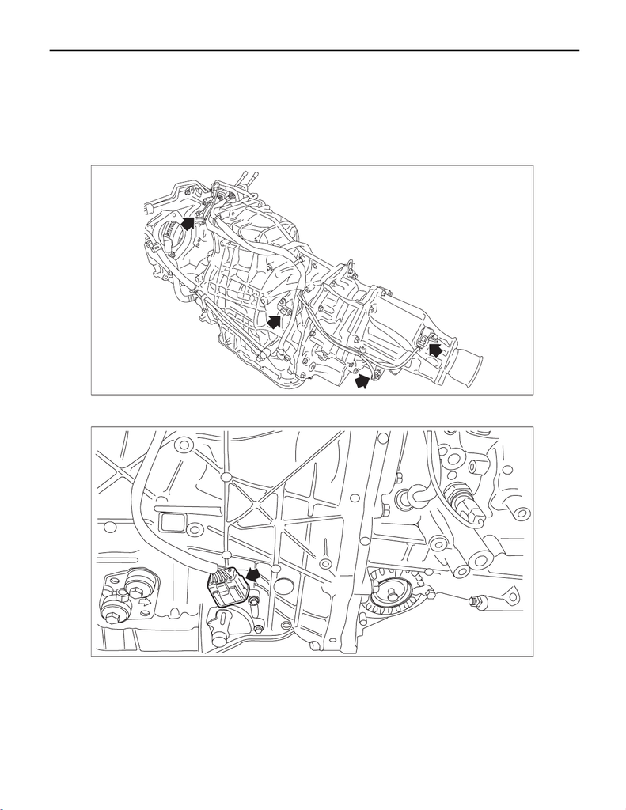

CVT(TR690)-123

Transmission Harness

CONTINUOUSLY VARIABLE TRANSMISSION

21.Transmission Harness

A: REMOVAL

2) Prepare for overhaul. <Ref. to CVT(TR690)-139, Preparation for Overhaul.>

3) Remove the transmission harness ground terminal and remove the harness connectors from front wheel

speed sensor, rear wheel speed sensor and secondary speed sensor.

CVT00587

AT-07402

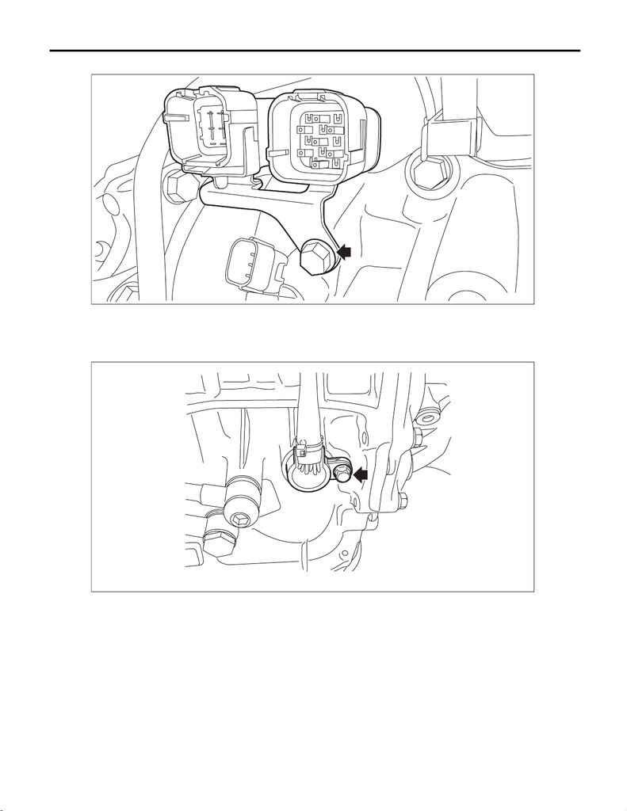

CVT(TR690)-124

Transmission Harness

CONTINUOUSLY VARIABLE TRANSMISSION

5) Remove the transmission harness stay.

6) Remove transmission harness connector and inhibitor harness connector from harness stay.

7) Remove the control valve body. <Ref. to CVT(TR690)-112, REMOVAL, Control Valve Body.>

8) Remove the mounting bolt to pull out the bushing of transmission harness from transmission case round

hole.

9) Remove the harness clip from transmission assembly.

AT-07403

AT-05454

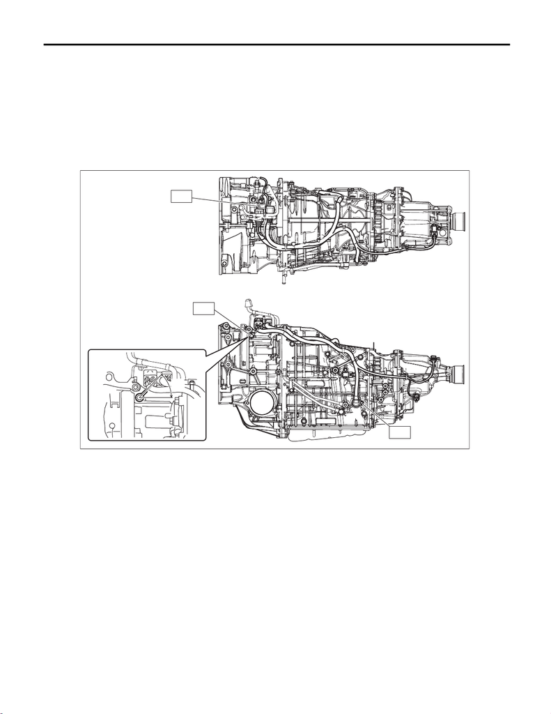

CVT(TR690)-125

Transmission Harness

CONTINUOUSLY VARIABLE TRANSMISSION

B: INSTALLATION

Install in the reverse order of removal.

NOTE:

• Use new O-rings.

• Do not impact or bend the transmission harness because it has the oil temperature sensor inside.

• Install the transmission ground terminal at an approximately 45° angle (A).

Tightening torque:

T1: 5 N·m (0.5 kgf-m, 3.7 ft-lb)

T2: 16 N·m (1.6 kgf-m, 11.8 ft-lb)

C: INSPECTION

1) Visually check the harness and connector for damage or crack.

2) Check the harness terminal for rust, disconnection or poor contact.

3) Check the continuity between harness terminals and oil temperature sensor.

NOTE:

Refer to WIRING SECTION for transmission harness terminal and oil temperature sensor terminal. <Ref. to

WI-148, WIRING DIAGRAM, CVT Control System.>

Harness continuity standard

Less than 1

Ω

Oil temperature sensor standard

Approx. 2.6 k

Ω

(at 20°C)

CVT00498

T1

T2

T2

(A)